# Reproducible Research: Peer Assessment 1

## Loading and preprocessing the data

### Setup the data files

First, establish some settings regarding where the data is located:

```r
url = "https://d396qusza40orc.cloudfront.net/repdata%2Fdata%2Factivity.zip"
zipFile = "activity.zip"
dataDirectory = "data"
dataFile = "activity.csv"
```

Then, perform data caching. Check if the required data is already stored in the working directory. If the data has already been extracted into the “data” directory as a csv file, then nothing needs to be done at this stage. If the data esists only as a zip file in the working directory, then extract the data into a csv file. And if the data is not present at all, download and extract the data automatically from the source URL.

```r
# Checks if the csv data exists
dataFilePath = paste(dataDirectory, dataFile, sep="/")
if(!file.exists(dataFilePath)){
    # Create the data directory if not already present
    if(!file.exists(dataDirectory)){
        dir.create(dataDirectory)
    }
    # Download the zip file from URL if its not already in working directory
    if (!file.exists(zipFile)) {
        download.file(url, destfile = zipFile, mode="wb")
    }
    # unzip the contents of the zip file into data directory
    unzip(zipFile, exdir=dataDirectory)
}
```

### Loading the data

Since it has now been established that the data exists in the data directory, we can load it into a data frame.

```r
df = read.csv(dataFilePath)
```

### Preprocess the data

The data contains lots of missing values which interfere and skew the data, creating a disproportionate number of false zeroes if not removed. So a new column is created which flags all the rows with that do not contain missing values, so that all other rows can be filtered out when necessary.

```r
library(dplyr)
df <- mutate(df, complete = complete.cases(df))
```

The data also contains a date field, so we need to convert the items in that column to be date objects instead of strings.

```r
library(lubridate)
df$date = ymd(df$date)
```

The intervals are essentially time stamps, it will be useful to create a column that has actual times.

```r
# add a column that converts the 5 minute intervals into actual times
df = mutate(df, interval.time = as.POSIXct(formatC(interval, width=4, flag="0"),
                                           format="%H%M"))
```

## What is mean total number of steps taken per day?

### Visualising frequency of total daily steps

A histogram is plotted to give us an idea of how the frequencies for different number of steps are distributed.

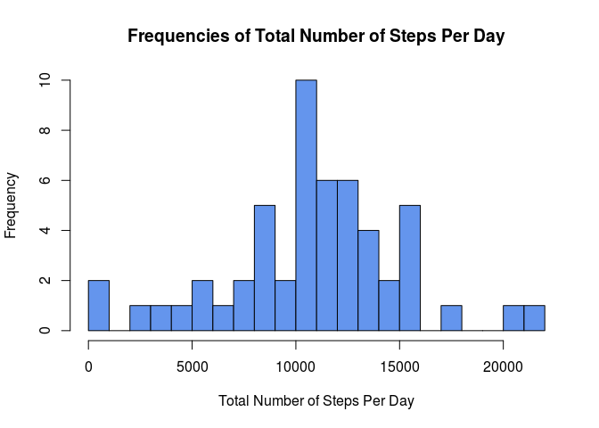

```r
# Filter out rows with missing values, then group by date, and sum over the
# step values
df.StepsPerDay <- summarise(group_by(df[df$complete,], date),
                            total.steps=sum(steps, na.rm=TRUE))
# Plot it
hist(df.StepsPerDay$total.steps, breaks=20, col="cornflowerblue",
     xlab="Total Number of Steps Per Day",
     main="Frequencies of Total Number of Steps Per Day")
```

A value of 20 breaks reveals regions which may be skewing the data. If the rows with missing data had not been filtered out then we would see a large spike in the frequency for zero steps. This spike occurs even when the `na.rm=TRUE` option is used in the `sum()` and `mean()` functions. This is because `sum()` returns 0 if it is asked to sum over a vector composed exclusively of NAs. So by the time the `mean()` function is called, any values which should have been NAs are now zeroes, and `mean()` does not (and should not) filter out zeroes.

A smaller number of breaks would hide the presence of such a problematic peak from our view, due to the very small frequencies for steps higher than 0 but less than 5000.

### Mean and median of total daily steps

We can find out what the mean and median number of total daily steps is.

```r
mean.dailySteps <- mean(df.StepsPerDay$total.steps, na.rm=TRUE)
median.dailySteps <- median(df.StepsPerDay$total.steps, na.rm=TRUE)
```

```r
mean.dailySteps
```

```
## [1] 10766.19
```

```r
median.dailySteps
```

```
## [1] 10765
```

We find that the mean number of total daily steps is **10766.19** and the median number of total daily steps is **10765**. Both values are very close together, meaning that both are good measures of centrality for this data.

## What is the average daily activity pattern?

The average number of steps taken, averaged across all days can be plotted.

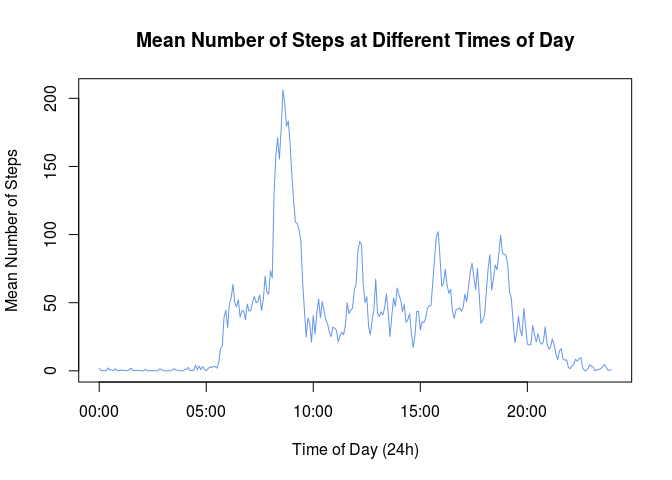

```r
# group by the five minute intervals, and average out the number of steps
# accross all days.
group.byInterval <- group_by(df[df$complete,], interval)
df.AvgStepsByInterval <- summarise(group.byInterval,
                                   mean.steps=mean(steps, na.rm=TRUE))

# add a column that converts the 5 minute intervals into actual times
df.AvgStepsByInterval = mutate(df.AvgStepsByInterval,
                               interval.time = as.POSIXct(formatC(interval,
                                                                  width=4,
                                                                  flag="0"),
                                                          format="%H%M"))

# Finally plot it
with(df.AvgStepsByInterval, plot(mean.steps~interval.time, type="l",
                                 col="cornflowerblue",
                                 xlab="Time of Day (24h)",
                                 ylab="Mean Number of Steps",
                                 main="Mean Number of Steps at Different Times of Day"))
```

From the plot we can see that on average, the greatest amount of activity occurs in the morning sometime between 5 am and 10am. We can calculate the exact time interval that receives the most activity.

```r
maxsteps = max(df.AvgStepsByInterval$mean.steps)
maxsteps.row = df.AvgStepsByInterval[df.AvgStepsByInterval$mean.steps == maxsteps, ]
maxsteps.interval = maxsteps.row[[1,"interval"]]
maxsteps.interval
```

```
## [1] 835
```

This tells us that the time interval that on averave receives the most activity is **835**, which corresponds to the time **8:35**

## Imputing missing values

There are a number of days/intervals where there are missing values (coded as NA). The presence of missing days may introduce bias into some calculations or summaries of the data.

The total number of missing values in the dataset (i.e. the total number of rows with NAs) is:

```r
sum(!df$complete)
```

```
## [1] 2304
```

That is a lot of missing values! One strategy is to simply filter out the rows that contain missing values, as was done in previous sections of this document. Another approach is to replace them with some reasonable values.

Since the average number of steps for each interval period has already been calculated, then this provides a convenient, and useful set of values to replace the missing values.

A new dataframe will be created that contains the filled in values.

```r
df.filled <- df
# For all rows in which there is missing data, replace the steps value to be the
# average steps value for that particular interval
for (i in which(!df.filled$complete)){
    df.filled[i,]$steps = subset(df.AvgStepsByInterval,
                                 interval == df.filled[i,]$interval)$mean.steps[1]
}
```

A histogram is plotted to give us an idea of how the frequencies for different number of steps are distributed.

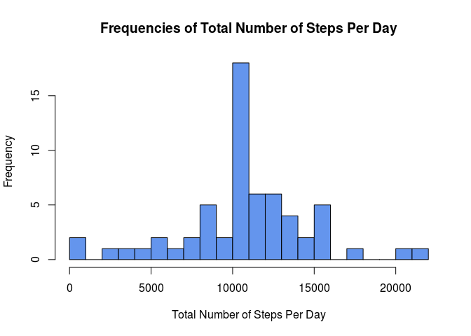

```r
# Filter out rows with missing values, then group by date, and sum over the
# step values
df.filled.StepsPerDay <- summarise(group_by(df.filled, date),
                            total.steps=sum(steps, na.rm=TRUE))
# Plot it
hist(df.filled.StepsPerDay$total.steps, breaks=20, col="cornflowerblue",
     xlab="Total Number of Steps Per Day",
     main="Frequencies of Total Number of Steps Per Day")
```

The only visible difference between the previous strategy of eliminating rows with missing data and the current strategy of replacing the missing values with averages for time periods is that the peak has been amplified.

We can look at the mean and median to see if any changes have occured there.

```r
filled.mean.dailySteps <- mean(df.StepsPerDay$total.steps, na.rm=TRUE)
filled.median.dailySteps <- median(df.StepsPerDay$total.steps, na.rm=TRUE)
filled.mean.dailySteps
```

```
## [1] 10766.19
```

```r
filled.median.dailySteps
```

```
## [1] 10765
```

However, if we draw a histogram using the unfiltered and non-filled data, we can see that there is a skew in the data, with a large peak towards zero.

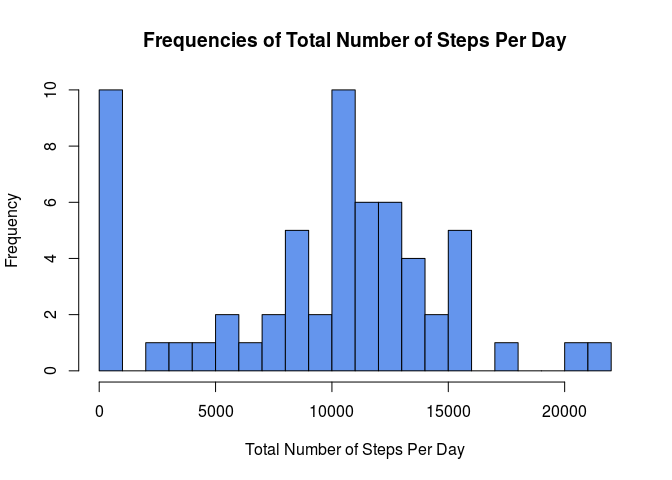

```r
# Filter out rows with missing values, then group by date, and sum over the
# step values
df.unfiltered.StepsPerDay <- summarise(group_by(df, date),
                            total.steps=sum(steps, na.rm=TRUE))
# Plot it
hist(df.unfiltered.StepsPerDay$total.steps, breaks=20, col="cornflowerblue",
     xlab="Total Number of Steps Per Day",
     main="Frequencies of Total Number of Steps Per Day")
```

This peak skewed peak does influence the mean and median, shifting them over quite a bit towards zero.

```r
unfiltered.mean.dailySteps <- mean(df.unfiltered.StepsPerDay$total.steps, na.rm=TRUE)
unfiltered.median.dailySteps <- median(df.unfiltered.StepsPerDay$total.steps, na.rm=TRUE)
unfiltered.mean.dailySteps
```

```
## [1] 9354.23
```

```r
unfiltered.median.dailySteps
```

```
## [1] 10395
```

## Are there differences in activity patterns between weekdays and weekends?

Create a new factor variable in the dataset with two levels – “weekday” and “weekend” indicating whether a given date is a weekday or weekend day.

```r
# Create new column indicating if the column represents a weekday or weekend.
df.filled <- mutate(df.filled,
       week.indicator = factor(ifelse(is.element(wday(df.filled$date, label=TRUE),
       c("Sat","Sun")), "weekend", "weekday"), labels=c("weekday", "weekend")))
```

We can see slight differences in activity for diffferent time intervals between weekdays and weekends.

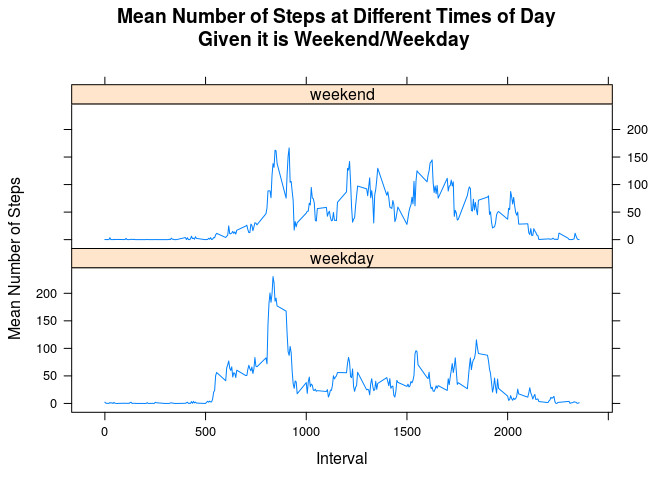

```r
# group by the five minute intervals, and average out the number of steps
# accross all days.
group.byInterval_and_weekIndicator <- group_by(df.filled,
                                               interval, week.indicator)

df.AvgStepsByInterval_and_weekIndicator <- summarise(group.byInterval_and_weekIndicator,
                                   mean.steps=mean(steps, na.rm=TRUE))

# add a column that converts the 5 minute intervals into actual times
df.AvgStepsByInterval_and_weekIndicator = mutate(df.AvgStepsByInterval_and_weekIndicator,
                               interval.time = as.POSIXct(formatC(interval,
                                                                  width=4,
                                                                  flag="0"),
                                                          format="%H%M"))

# Finally plot it
library(lattice)
xyplot(mean.steps~(interval) | week.indicator,
       data=df.AvgStepsByInterval_and_weekIndicator,
       layout=c(1,2), type="l",
       main="Mean Number of Steps at Different Times of Day\nGiven it is Weekend/Weekday ",
       xlab="Interval",
       ylab="Mean Number of Steps",)
```